# R for Psychologists - part II

ggplotting and long data

DrMowinckels

2019-07-17

It’s been a very long time since I wrote anything. Life has been unexpectedly overwhelming for a period, still is I guess, but one musters on. I’m sitting in old town Fredrikstad while my cat is getting some tests at the vets’, so I finally get some time and want to write something here. And we will continue with some R for Psychologists.

I my first R for Psychologists post we really dove into it. I very quickly covered getting SPSS data into R, doing some data wrangling (altering the data), plotting, and running a simple linear model. That was really quite the mountful of topics to cover. In this part, I’ll take you more through plotting. You might think that is a weird place to dive into more, but there are perfectly good reasons for it (aside from me loving to make pretty plots). Plotting in R through `ggplot2` really is a way to get to understand how to organise and alter data in R to suit your needs. Getting data into the correct shape, with variables correctly made in to numerics, categorical (factors) etc. is very important. Not only does it affect how your plots end up, but will also dictate how your analyses work out. Just as in SPSS, data need to have the correct `types` or `classes` in order for the analyses to work correctly.

Let’s stars by opening the R-project we started with last time. If you have not been working in R since the last tutorial, you should be able to open RStudio, and our project will open immediately, and your script from last time should already be ready for you to work with. Otherwise, either navigate to the folder where your project was made and click on the `Rproj`-file, or in the top right corner of RStudio, click the drop-down menu next to the R-project icon and select the `R-start` project.

Our script from last time should look something like this:

```r
library(rio)
library(tidyverse)

# Start with importing the data
eData = rio::import("SPSS/experim.sav") %>%
  # then recode sex to Male and Female
  mutate(
    sex = factor(sex, labels=c("Male","Female")),
    id = factor(id))

# Gather depression variables into a tall depression data format.
eData_tall = eData %>%
  gather(time, depress, c("depress1", "depress2", "depress3")) %>%
  mutate(time = as.integer(gsub("[[:alpha:]]","",time))) %>%
  arrange(id)

# Do a linear regression on depression over time
lm(depress~time, data=eData_tall) %>%
  broom::tidy()

# plot the regression
eData_tall %>%
  ggplot(aes(x=time, y=depress)) +
  geom_jitter() +
  geom_smooth(method="lm")
```

In this script we have already some both a plot (`ggplot`) and some data wrangling (`mutate`).

## Ggplotting

`ggplot2` is a very powerful package for making plots. People who are used to plotting in SPSS or in base-R, find it hard to understand. I did to in the beginning, and it tok me some time before I understood how it works and how to make my data into the shape that it needs for the plots to end up just as I like them. I know many researchers that will make simple plots in R or excel, and then get the plots into some vector program like Photoshop or Inkscape to make them exactly as they like. I did that too for a long time, but now I try to make sure my plots are reproduciably made through R, without the need for tweaking later so it looks nice and correct. Let’s face it, that stuff takes a lot of time, and needs to be fixed with almost every co-author comment and review. So much time spent fixing.

But as I said last time, it takes time to get good enough in R to not need that step, and making the scripts also takes time. There are no quick-fix solutions, but I believe R makes the fixes faster, as they will be minor tweaks, or if new data comes in, just load the new data, and rerun, and presto all the plots are updated.

Anyway, let’s get into it. Lets have a look at the plot from last time, at the end of our script.

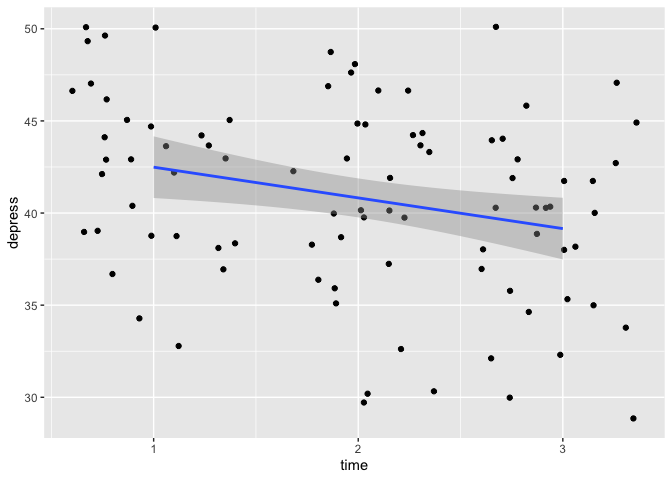

```r
# plot the regression
eData_tall %>%
  ggplot(aes(x=time, y=depress)) +
  geom_jitter() +
  geom_smooth(method="lm")
```

Alrighty, we have the individual data points for depression (y-axis) at each timepoint (x-axis) for all individuals as the scatter plot, and a regression-line fitted to that data. To reiterate what the code is doing: *“Take `eData_tall`, plot with time on the x-axis, depress on the y-axis, create a scatter plot with a little bit of random noise, and add a regression line using a linear model.”* Let’s break that down a little bit by looking at the data again.

```r
eData_tall %>%
  glimpse()
```

```
## Rows: 90
## Columns: 17
## $ id       <fct> 1, 1, 1, 2, 2, 2, 3, 3, 3, 4, 4, 4, 5, 5, 5, 6, 6, 6, 7, 7, …
## $ sex      <fct> Male, Male, Male, Male, Male, Male, Male, Male, Male, Male, …
## $ age      <dbl> 19, 19, 19, 21, 21, 21, 30, 30, 30, 23, 23, 23, 26, 26, 26, …
## $ group    <dbl> 1, 1, 1, 2, 2, 2, 1, 1, 1, 2, 2, 2, 1, 1, 1, 2, 2, 2, 1, 1, …
## $ fost1    <dbl> 32, 32, 32, 37, 37, 37, 47, 47, 47, 50, 50, 50, 44, 44, 44, …
## $ confid1  <dbl> 20, 20, 20, 29, 29, 29, 11, 11, 11, 15, 15, 15, 17, 17, 17, …
## $ fost2    <dbl> 28, 28, 28, 36, 36, 36, 42, 42, 42, 48, 48, 48, 37, 37, 37, …
## $ confid2  <dbl> 25, 25, 25, 30, 30, 30, 16, 16, 16, 16, 16, 16, 20, 20, 20, …
## $ fost3    <dbl> 23, 23, 23, 34, 34, 34, 41, 41, 41, 45, 45, 45, 32, 32, 32, …
## $ confid3  <dbl> 30, 30, 30, 34, 34, 34, 20, 20, 20, 14, 14, 14, 26, 26, 26, …
## $ exam     <dbl> 82, 82, 82, 90, 90, 90, 60, 60, 60, 52, 52, 52, 70, 70, 70, …
## $ mah_1    <dbl> 0.3469978, 0.3469978, 0.3469978, 10.2401804, 10.2401804, 10.…
## $ DepT1gp2 <dbl> 0, 0, 0, 1, 1, 1, 0, 0, 0, 0, 0, 0, 1, 1, 1, 0, 0, 0, 0, 0, …
## $ DepT2Gp2 <dbl> 0, 0, 0, 1, 1, 1, 0, 0, 0, 0, 0, 0, 1, 1, 1, 0, 0, 0, 0, 0, …
## $ DepT3gp2 <dbl> 0, 0, 0, 1, 1, 1, 0, 0, 0, 0, 0, 0, 0, 0, 0, 0, 0, 0, 0, 0, …
## $ time     <int> 1, 2, 3, 1, 2, 3, 1, 2, 3, 1, 2, 3, 1, 2, 3, 1, 2, 3, 1, 2, …
## $ depress  <dbl> 44, 43, 40, 50, 47, 45, 43, 43, 43, 44, 44, 40, 46, 47, 42, …
```

So `time` is an *integer* with three values (1-3) and `depress` is a double precision number with a depression score. Again, notice how in the `id` column, the subject identifiers are repeated in three rows, last time we made this *long* dataset where participants had *as many rows as number of time observations*. This is a very convenient way of working with data, and while it might take a little time to get used to, it does make a lot of sense. When you have data repeating over time, the *same data* repeated over time, it is easier to get an overview of in long format so you dont need to scroll sideways and loose your navigation points (id) too easily.

Now,last time, we only made *depress* into long format. But techincally, most of the data in this dataset is repeated, and thankfully named in such a way that it is quite easy for us to reshape the data. When we have done this, we can make some really nice plots too!

## Reshape the data

We’ll go back to the original `eData` file for this.

```r
eData %>% glimpse()
```

```
## Rows: 30
## Columns: 18
## $ id       <fct> 4, 10, 9, 3, 12, 11, 6, 5, 8, 13, 14, 1, 15, 7, 2, 27, 25, 1…
## $ sex      <fct> Male, Male, Male, Male, Male, Male, Male, Male, Male, Male, …
## $ age      <dbl> 23, 21, 25, 30, 45, 22, 22, 26, 23, 21, 23, 19, 23, 19, 21, …
## $ group    <dbl> 2, 2, 1, 1, 2, 1, 2, 1, 2, 1, 2, 1, 1, 1, 2, 1, 1, 1, 2, 1, …
## $ fost1    <dbl> 50, 47, 44, 47, 46, 39, 32, 44, 40, 47, 38, 32, 39, 36, 37, …
## $ confid1  <dbl> 15, 14, 12, 11, 16, 13, 21, 17, 22, 20, 28, 20, 21, 24, 29, …
## $ depress1 <dbl> 44, 42, 40, 43, 44, 43, 37, 46, 37, 50, 39, 44, 47, 38, 50, …
## $ fost2    <dbl> 48, 45, 39, 42, 45, 40, 33, 37, 40, 45, 37, 28, 35, 32, 36, …
## $ confid2  <dbl> 16, 15, 18, 16, 16, 20, 22, 20, 23, 25, 27, 25, 26, 28, 30, …
## $ depress2 <dbl> 44, 42, 40, 43, 45, 42, 36, 47, 37, 48, 36, 43, 47, 35, 47, …
## $ fost3    <dbl> 45, 44, 36, 41, 43, 39, 32, 32, 40, 46, 32, 23, 35, 30, 34, …
## $ confid3  <dbl> 14, 18, 19, 20, 20, 22, 23, 26, 26, 27, 29, 30, 30, 32, 34, …
## $ depress3 <dbl> 40, 40, 38, 43, 43, 38, 35, 42, 35, 46, 34, 40, 47, 35, 45, …
## $ exam     <dbl> 52, 55, 58, 60, 58, 62, 59, 70, 60, 70, 72, 82, 79, 80, 90, …
## $ mah_1    <dbl> 0.5699842, 1.6594031, 3.5404715, 2.4542143, 0.9443036, 1.625…
## $ DepT1gp2 <dbl> 0, 0, 0, 0, 0, 0, 0, 1, 0, 1, 0, 0, 1, 0, 1, 1, 0, 1, 0, 0, …
## $ DepT2Gp2 <dbl> 0, 0, 0, 0, 1, 0, 0, 1, 0, 1, 0, 0, 1, 0, 1, 0, 0, 1, 0, 0, …
## $ DepT3gp2 <dbl> 0, 0, 0, 0, 0, 0, 0, 0, 0, 1, 0, 0, 1, 0, 1, 0, 0, 0, 0, 0, …
```

Notice that in the dataset, all variables that are repeated have a number in their variable name, except `mah_1` which is not repeated, but we can work with that. This logic helps us a lot, as it will make it possible for us to wrangle the data into shape using that logic.

As we did last time, we will use the `gather` function from `tidyverse` to make the data long, and use the logic of numbers in the column names to helps to get the data into shape.

```r
eData %>%
  gather(colName, value, matches("[123]"))
```

```
##     id    sex age group exam  colName      value
## 1    4   Male  23     2   52    fost1 50.0000000
## 2   10   Male  21     2   55    fost1 47.0000000
## 3    9   Male  25     1   58    fost1 44.0000000
## 4    3   Male  30     1   60    fost1 47.0000000
## 5   12   Male  45     2   58    fost1 46.0000000
## 6   11   Male  22     1   62    fost1 39.0000000
## 7    6   Male  22     2   59    fost1 32.0000000
## 8    5   Male  26     1   70    fost1 44.0000000
## 9    8   Male  23     2   60    fost1 40.0000000
## 10  13   Male  21     1   70    fost1 47.0000000
## 11  14   Male  23     2   72    fost1 38.0000000
## 12   1   Male  19     1   82    fost1 32.0000000
## 13  15   Male  23     1   79    fost1 39.0000000
## 14   7   Male  19     1   80    fost1 36.0000000
```

[output cut: 376 more lines]

As I usually do when I work, I start by running commands in my console, *without* saving the output (i.e. putting something to the left of an `=` sign of that command), so I can make sure the commands are doing what I expect. Let’s face it, we’ll never be computers, you will rarely write a command that does everything you want in one go.

In this case I said *“Take `eData`, gather all variables that matches with 1,2 or 3 in their variable name, and place all the variable names into a column named `colName` and the values of those columns into a variable called `value`”*

That was step one, now we want to make sure we have one column with the names of the columns *without* the numbers in one variable, and the numbers into a column named `time`. We are going to use `mutate` for that in this case.

```r
eData %>%
  gather(colName, value, matches("[123]")) %>%
  mutate(time = parse_number(colName),
         colName = gsub("[[:digit:]]","",colName))
```

```
##     id    sex age group exam colName      value time
## 1    4   Male  23     2   52    fost 50.0000000    1
## 2   10   Male  21     2   55    fost 47.0000000    1
## 3    9   Male  25     1   58    fost 44.0000000    1
## 4    3   Male  30     1   60    fost 47.0000000    1
## 5   12   Male  45     2   58    fost 46.0000000    1
## 6   11   Male  22     1   62    fost 39.0000000    1
## 7    6   Male  22     2   59    fost 32.0000000    1
## 8    5   Male  26     1   70    fost 44.0000000    1
## 9    8   Male  23     2   60    fost 40.0000000    1
## 10  13   Male  21     1   70    fost 47.0000000    1
## 11  14   Male  23     2   72    fost 38.0000000    1
## 12   1   Male  19     1   82    fost 32.0000000    1
## 13  15   Male  23     1   79    fost 39.0000000    1
## 14   7   Male  19     1   80    fost 36.0000000    1
```

[output cut: 376 more lines]

We are mutating two variables. Firstly, we are extracting any numder from the `colName` variable and placing that into a new variable called `time` wuth `parse_number`, then we are removing all digits from `colName` and overwriting it using `gsub`. I like this output for now, so we are going to save it, since this data is more like the data I want, I’m overwriting `eData_tall`.

```r
eData_tall <- eData %>%
  gather(colName, value, matches("[123]")) %>%
  mutate(time = parse_number(colName),
         colName = gsub("[[:digit:]]","",colName))
```

Because the data are in such a long format now, such that even different types of observations are in one column (`value`), made distinct by the information in the `colName` variable, we can actually plot them all in one `ggplot` command!

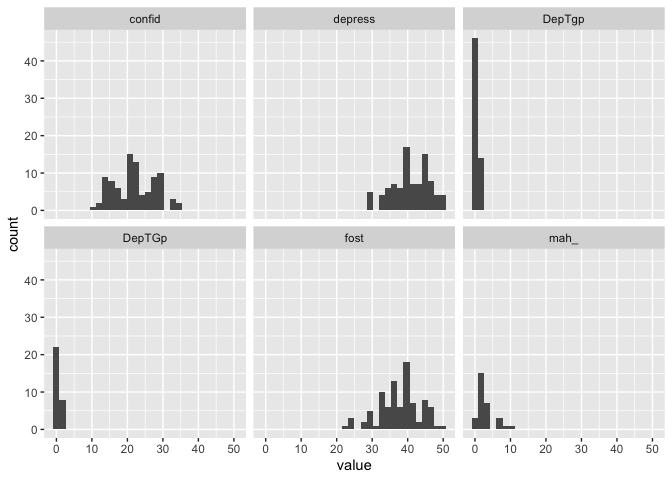

```r
eData_tall %>%
  ggplot(aes(x=value)) +
  geom_histogram() +
  facet_wrap(~colName)
```

Look at that, suddenly we have a histogram for each of the variables! What we did there was *“Take the data in `eData_tall` and plot `value` on the x-axis, make histograms of that, and create different facets (panels) using the information in `colName`”*. Now we also see that apparently there was a naming inconsistency with the `DepTgp` variables, where one was typed as `Gp` instead of `gp`. We will fix that before we continue.

```r
eData_tall <- eData %>%
  gather(colName, value, matches("[123]")) %>%
  mutate(time = parse_number(colName),
         colName = gsub("[[:digit:]]","",colName),
         colName = gsub("Gp", "gp", colName, ignore.case = FALSE))
```

I’ve added another line to our `mutate` function, saying to replace any instance of “Gp”, and “gp” and to make sure to do this as case sensitive. Let’s see if our plot looks better now:

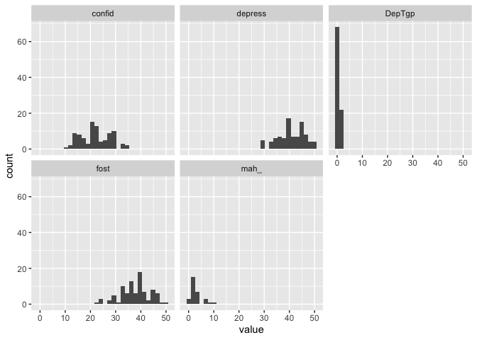

```r
eData_tall %>%
  ggplot(aes(x=value)) +
  geom_histogram() +
  facet_wrap(~colName)
```

We can build more on that, because we also have the `time` variable, we can create a facet grid with histograms for each variable at each timepoint very easily

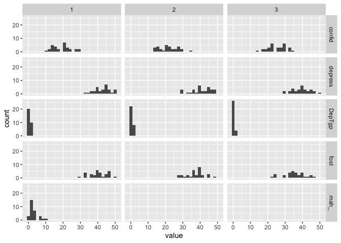

```r
eData_tall %>%
  ggplot(aes(x=value)) +
  geom_histogram() +
  facet_grid(colName~time)
```

I think that’s pretty neat. We can do that because the data is in long format, and everything is contained in just some few columns, and ggplot can therefore make some nice plots out of, rather than having to tell it about the 5 different columns the data would otherwise be in (one for each variable). Distribution plots might not be the most interesting though, let’s look at a plot more similar like the one we did before, scatter plot with a regression line.

The basic’s are pretty much the same as above:

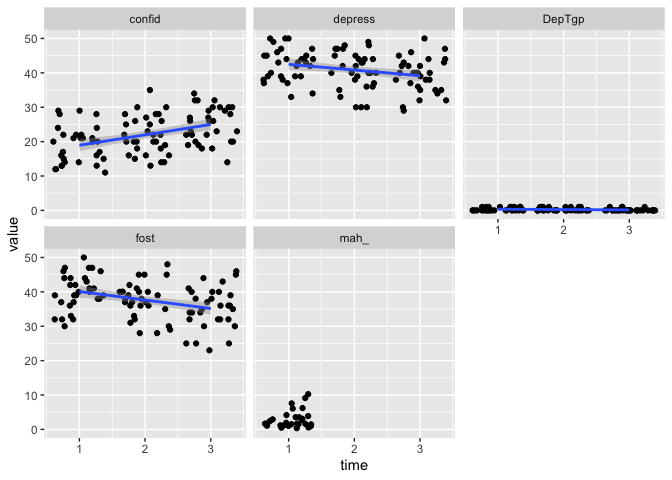

```r
eData_tall %>%
  ggplot(aes(x=time, y=value)) +
  geom_jitter() +
  geom_smooth(method = "lm") +
  facet_wrap(~colName)
```

That’s looking much as expected! And we can see that `mah_` only has observations at *one* timepoint, so you would not be able to fit a regression line with that. It’s no matter for us now. Since we are interested to have a look across time, we might as well omit `mah_` from the plot. We want the data to remain in the main data, but just not to plot it.

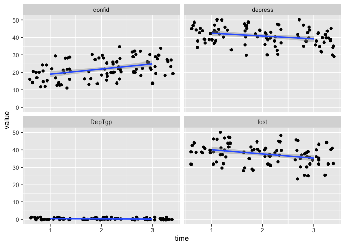

```r
eData_tall %>%
  filter( colName != "mah_") %>%
  ggplot(aes(x=time, y=value)) +
  geom_jitter() +
  geom_smooth(method = "lm") +
  facet_wrap(~colName)
```

Now, we added a `filter` before we did `ggplot`. Here we are going *“Take `eData_tall` and filter away any rows where the value in `colName` is `mah_`, then make this ggplot”.* `DepTgp` is showing some odd behaviour though. It only has values of 0 and 1, and here indicates belonging to a treatment group or not. In R, we would call that variable a logical, i.e. it is a variable indicating if some statement is TRUE (1) or FALSE (0). A standard regression makes no sense in this case. Let’s also filter away these, as they are not interesting here, just like we did with `mah_`.

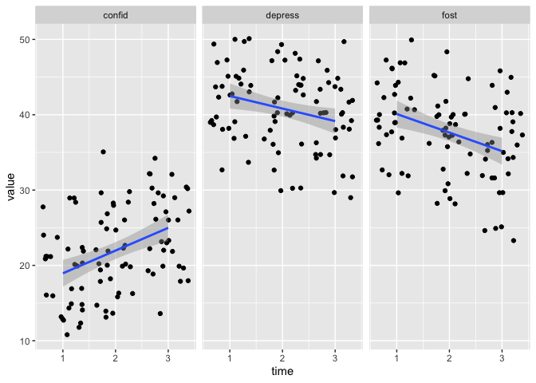

```r
eData_tall %>%
  filter( ! colName %in% c("mah_", "DepTgp")) %>%
  ggplot(aes(x=time, y=value)) +
  geom_jitter() +
  geom_smooth(method = "lm") +
  facet_wrap(~colName)
```

The `filter` now looks a little different than before. Rather than a `!=` (not equal to), we are using `%in%` and negating that (`!`) in front of the statement. `%in%` is a nice matching shortcut in R, that is vectorised. What that means is that rather than just taking one value to match against (like `!=` or `==`), it can take a series of values to match against. In this case we are going *“Take `eData_tall` and filter away any rows where the value in `colName` is eiter `mah_` or `DepTgp`, then make this ggplot”.*

Those plots are starting to look very nice. Let us also add some spaghetti in the background. By that I mean,let’s connect the subject data points with lines, so we can see the individual trends in the background of the refression. This should also give us an idea whether there are datapoints that behave oddly over time.

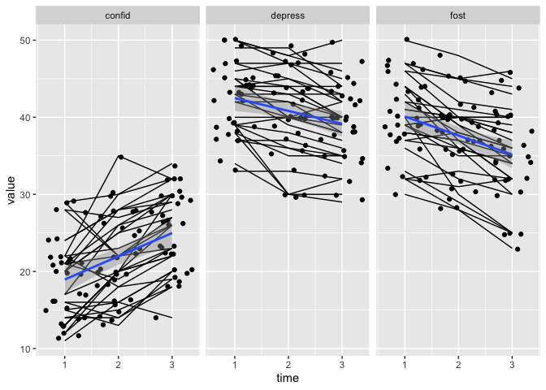

```r
eData_tall %>%
  filter( ! colName %in% c("mah_", "DepTgp")) %>%
  ggplot(aes(x=time, y=value)) +
  geom_jitter() +
  geom_line(aes(group=id)) +
  geom_smooth(method = "lm") +
  facet_wrap(~colName)
```

That is looking very odd. The points and the lines are not connecting. That is beause we are using `geom_jitter`, which generates a little random noise for us so the dots don’t plot on top of each other and in very very straight lines. But this happens independently from `geom_line`, so the dots and lines dont know where they should connect.

We can fix that,and I’ll break the process down, hopefully to make it understandable. First, let’s replace `geom_jitter` with `geom_point` and see what happens.

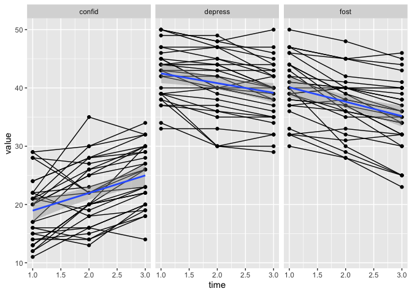

```r
eData_tall %>%
  filter( ! colName %in% c("mah_", "DepTgp")) %>%
  ggplot(aes(x=time, y=value)) +
  geom_point() +
  geom_line(aes(group=id)) +
  geom_smooth(method = "lm") +
  facet_wrap(~colName)
```

The dots and lines are connecting, good. Overplotting in this case is actally not too bad, in many cases like this, I’d leave it be. But, I mostly have data with many more points, and so I need to find a way to reduce overplotting.

We will be using the `ggplot2`’s function `position_dodge` to introduce noise to both the lines and the points. We will also need to make sure both the lines and the dots have the correct group setting, letting ggplot know that lines and dots are grouped by `id`, meaning that data with the same values in `id` belong together.

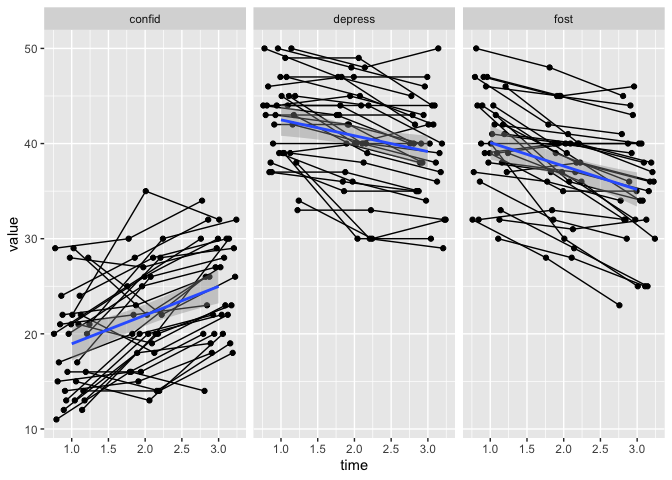

```r
eData_tall %>%
  filter( ! colName %in% c("mah_", "DepTgp")) %>%
  ggplot(aes(x=time, y=value)) +
  geom_point(aes(group=id), position = position_dodge(width=.5)) +
  geom_line(aes(group=id), position = position_dodge(width=.5)) +
  geom_smooth(method = "lm") +
  facet_wrap(~colName)
```

See, now there is a little more space between the points so you can see them all, but everything still connects correctly. The lines and points are a little too domineering , so let’s reduve their opacity/transparency, byt reducing the àlpha` setting for those two geoms.

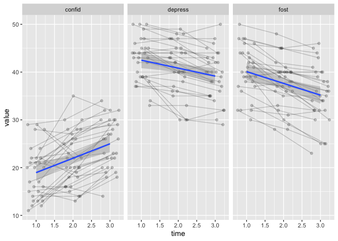

```r
dodge <- position_dodge(width = .5)
eData_tall %>%
  filter( ! colName %in% c("mah_", "DepTgp")) %>%
  ggplot(aes(x=time, y=value)) +
  geom_line(aes(group=id), position = dodge, alpha = .2) +
  geom_point(aes(group=id),position = dodge, alpha = .2) +
  geom_smooth(method = "lm") +
  facet_wrap(~colName)
```

When we adjust the `alpa`, we can also see that there still is some overplotting. This is because we cannot create noise in the y-axis, that would be akin to data-manipulation, we should not enter noise in the obsvered measurements. But the alpa helps us see that, and now the regression line is a little more obious too.

The last thing for today, is changing the regression lines and CI band colour, to make it “pop” more.

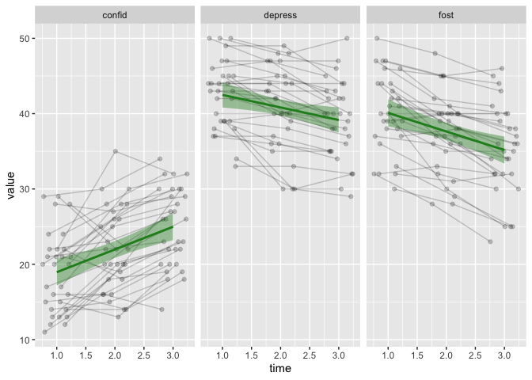

```r
dodge <- position_dodge(width = .5)
eData_tall %>%
  filter( ! colName %in% c("mah_", "DepTgp")) %>%
  ggplot(aes(x=time, y=value)) +
  geom_line(aes(group=id), position = dodge, alpha = .2) +
  geom_point(aes(group=id),position = dodge, alpha = .2) +
  geom_smooth(method = "lm", colour = "forestgreen", fill = "forestgreen") +
  facet_wrap(~colName)
```

In this case, altering the colour is very easy, because we set the colour (line) and fill (CI band) to be a single value (not within aes). By setting the colour like this, all panels get the same. We could also use the `colName` variable to give each panel it’s own colour.

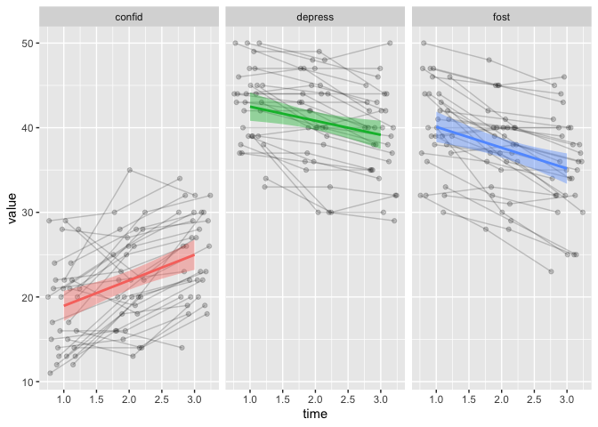

```r
dodge <- position_dodge(width = .5)
eData_tall %>%
  filter( ! colName %in% c("mah_", "DepTgp")) %>%
  ggplot(aes(x=time, y=value)) +
  geom_line(aes(group=id), position = dodge, alpha = .2) +
  geom_point(aes(group=id),position = dodge, alpha = .2) +
  geom_smooth(method = "lm", show.legend = FALSE,
              aes(colour=colName, fill=colName)) +
  facet_wrap(~colName)
```

that is pretty neat, right?

That’s all for this time. We’re explored more plots, and ways to change the data, so it becomes easy to plot in this faceted way.

Next time, we will be working on changing factors and factor levels both to make the data correctly portray what it should, and also to help us make our plots meaningful.